[O’Hara on GitHub](https://github.com/oharac)

# Eco-Detectives: chapter 3

Compiled on Tue Jun 26 08:09:38 2018 by ohara

```r
knitr::opts_chunk$set(fig.width = 6, fig.height = 4, fig.path = 'Figs/',
                      echo = TRUE, message = FALSE, warning = FALSE)

source('https://raw.githubusercontent.com/oharac/src/master/R/common.R')
```

# 1 Chapter 3: Probability and Probability Models

## 1.1 Pseudocode 3.1

Here we’re implementing a binomial probability distribution to plot the probability of finding $k$ successes out of $N$ attempts. Eqn 3.47 gives the probability of zero successes:

$$p(0, N) = (1 - p)^N$$
Eqn 3.48 gives the recursive formula to find $k$ successes based on the probability of finding $k - 1$ successes:
$$\begin{align*}
p(k, N) &= \binom{N}{k} p^k (1 - p)^{N - k}\\
&= \left(\frac{N - k + 1}{k}\right) \left(\frac{p}{1-p}\right) p(k-1, N)
\end{align*}$$

Start by choosing values for $p$ and $N$. Let’s start with $p = 0.25$ and $N = 10$.

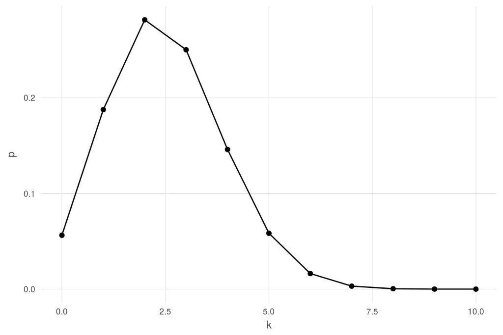

```r
p <- 0.25
N <- 10

k_vec <- 0:N
prob <- rep(NA, length(k_vec))

for (i in seq_along(k_vec)) {
  k <- k_vec[i]
  prob[i] <- ifelse(k == 0,
                    (1 - p)^N,
                      ### k = 0, so use 3.47
                    (N - k + 1)/(k) * (p)/(1 - p) * prob[i-1])
                      ### k > 0, so use 3.48 and refer to previous p(k-1, N)
}
binomial_df <- data.frame(k = k_vec, p = prob)

ggplot(binomial_df, aes(x = k, y = p)) +
  ggtheme_plot() +
  geom_line() +
  geom_point()
```

Let’s try non-iteratively…

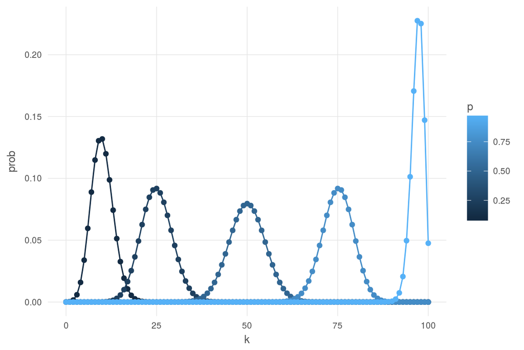

```r
N <- 100
p_vals <- c(0.1, 0.25, 0.5, 0.75, .97)

bin2_df <- data.frame(k = rep(0:N, times = length(p_vals)),
                     p = rep(p_vals, each = N + 1)) %>%
  mutate(prob = ifelse(k == 0,
                      (1 - p)^N,
                        ### k = 0, so use 3.47
                      choose(N, k) * p^k * (1 - p)^(N - k)))
                        ### k > 0, so use the original eq 3.44

ggplot(bin2_df, aes(x = k, y = prob, color = p)) +
  ggtheme_plot() +
  geom_line(aes(group = p)) +
  geom_point()
```

Note there’s a function `dbinom()` (and `pbinom`, `qbinom`, `rbinom`) that generate binomial density, distribution, quantile, and random numbers for a binomial distribution with `x`/`q`/`p`/`n` of outputs plus `size` (# trials) and `prob` (probability of success on each trial).

## 1.2 Pseudocode for multinomial

Instead of 3.44 use eq. 3.50 in the code; if we want it as a data frame, instead of using several values for $p$ across a single $k_1$, we can use different values for $k_2, k_3, ...$. Probably makes more sense to do it as a matrix if there are more than two or three $k_x$ values.

## 1.3 Pseudocode 3.2

Here we’re dealing with the Poisson distribution

$$p(k, t) = \frac{\lambda^k e^{-\lambda}}{k!} = \frac{(rt)^k e^{-rt}}{k!}$$

Specify $r$, $t$, and $cutoff$. Since $rt$ takes the place of $\lambda$, $\mathbb{E}[x] = rt$ and $Var(x) = rt$. We’ll iterate over values of $k$ until the cumulative probability gets close to 1, i.e. the CDF instead of the PDF.

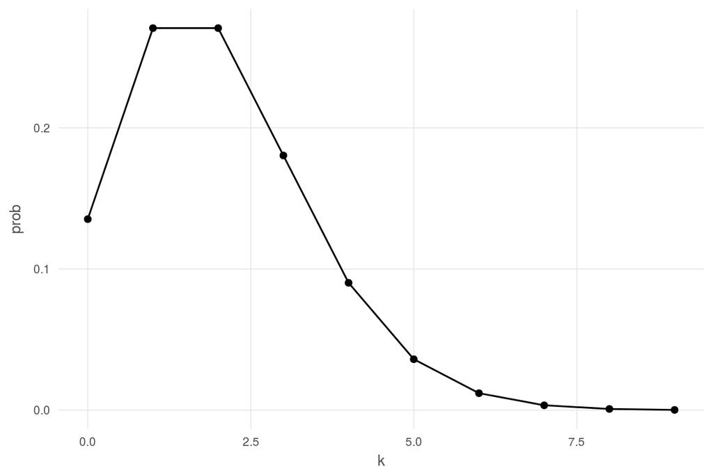

```r
r <- .05
t <- 40
cutoff <- 0.9999
k <- NA; prob = NA

i <- 1
k[1] <- 0
prob[1]  <- exp(-r*t)
sum_p <- prob[1]

while(sum_p < cutoff) {
  i <- i + 1
  k[i] <- k[i-1] + 1
  prob[i] <- r * t / k[i] * prob[i - 1]

  sum_p <- sum_p + prob[i]
}

poisson_df <- data.frame(k = k, prob = prob)

ggplot(poisson_df, aes(x = k, y = prob)) +
  ggtheme_plot() +
  geom_point() +
  geom_line()
```

try non-iteratively

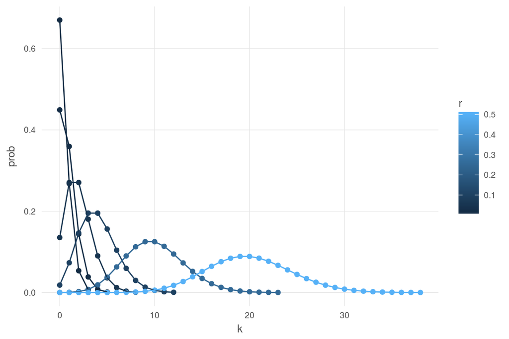

```r
r_vec <- c(0.01, 0.02, 0.05, .10, .25, .5)
t <- 40
cutoff <- 0.9999
k_max <- 100

poisson_df <- data.frame(k = rep(0:k_max, times = length(r_vec)),
                         r = rep(r_vec, each = k_max + 1),
                         prob = NA) %>%
  mutate(prob = exp(-r * t) * (r * t)^k / factorial(k)) %>%
  group_by(r) %>%
  mutate(CDF = cumsum(prob)) %>%
  ungroup() %>%
  filter(CDF < cutoff)

ggplot(poisson_df, aes(x = k, y = prob, color = r)) +
  ggtheme_plot() +
  geom_point() +
  geom_line(aes(group = r))
```

## 1.4 Pseudocode 3.3

Here we’re using a uniform distribution to select an integer result from a binomial distribution. This is like using a cdfbinom (probably qbinom in R?) to translate uniform randoms to binomial randoms. Let’s skip the iterative and go straight to vector.

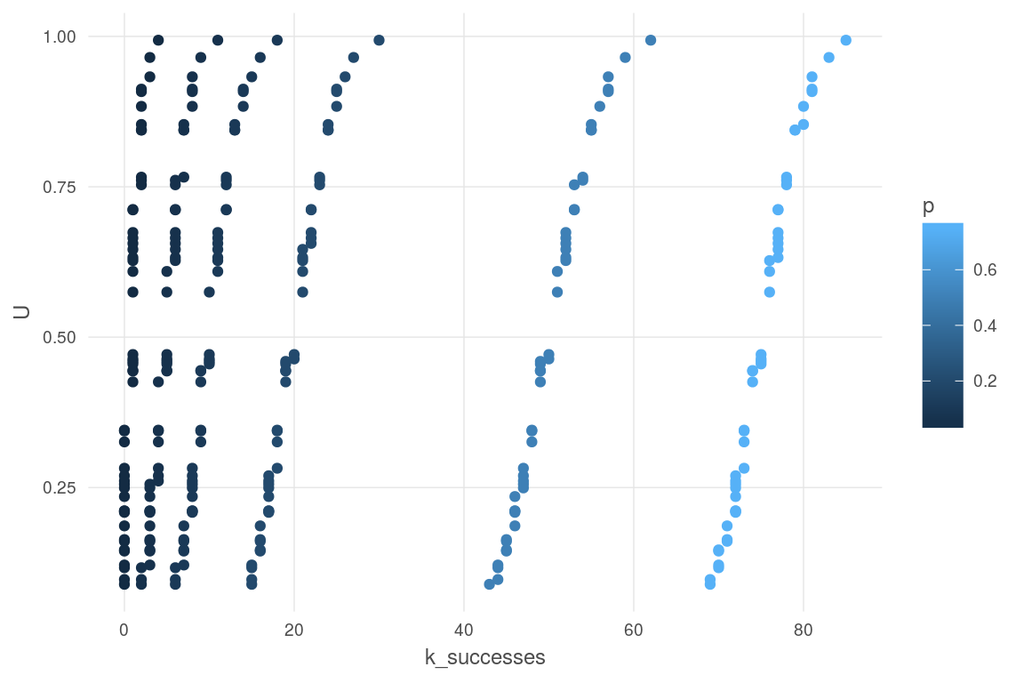

```r
qbinom1 <- function(N, k, p, U) {
  qbinom1_df <- data.frame(N = N,
                          k = rep(0:N, times = length(p_vec)),
                          p = rep(p_vec, each = N + 1)) %>%
    group_by(p) %>%
    mutate(pdf = choose(N, k) * p^k * (1 - p)^(N - k),
           cdf = cumsum(pdf)) %>%
    filter(cdf > U) %>%
    summarize(U = U, N = first(N), k_successes = first(k))

  return(qbinom1_df)
}

N <- 100
p_vec <- c(0.01, 0.05, 0.10, 0.2, 0.5, 0.75)

U <- runif(50)

qbinom_df <- lapply(U, FUN = function(x) {
  qbinom1(N, k, p_vec, x)
}) %>%
  bind_rows()

ggplot(qbinom_df, aes(y = U, x = k_successes, color = p)) +
  ggtheme_plot() +
  geom_point()
```

## 1.5 Pseudocode 3.4

A Monte Carlo approach to simple population model with process and observation uncertainty. This is based on Eq. 3.38, a simple population model based on exponential growth:
$$N_{t+1} = sN_t + b_t + W_t,$$
where $W_t$ represents process uncertainty, and
$$N_{obs,t} = N_t + V_t,$$
where $V_t$ represents observation uncertainty.

Let’s use the text values for $s = 0.8, b = 20$, and $N_0 = 50$. Try iterating over different values for $\sigma_N, \sigma_W, \sigma_V$.

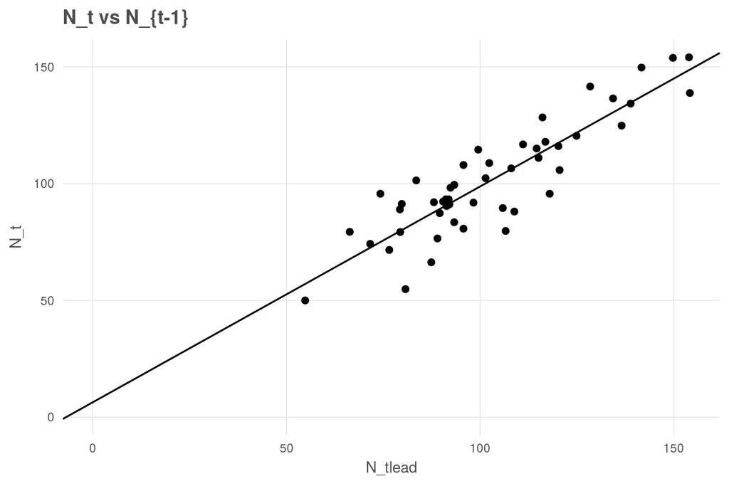

```r
pop_mdl <- function(s, b, N_0, sig_N, sig_W, sig_V) {
  t_vec <- 1:50
  N_vec <- rep(NA, 50)
  N_obs <- rep(NA, 50)

  for (t in t_vec) {
    if (t == 1) {
      N_vec[t] <- N_0
      N_obs[t] <- N_0 ### perfect observation in first time step
    } else {
      N_vec[t] <- s * N_vec[t - 1] + b + rnorm(n = 1, mean = 0, sd = sig_W)
      N_obs[t] <- N_vec[t] + rnorm(n = 1, mean = 0, sd = sig_V)
    }
  }
  N_df <- data.frame(t = t_vec,
                     N_t = N_vec,
                     N_obs = N_obs)
  return(N_df)
}

pop_1 <- pop_mdl(s = .8, b = 20, N_0 = 50, sig_N = NA, sig_W = 10, sig_V = 5) %>%
  mutate(N_tlead = lead(N_t))

pop_lm <- lm(N_t ~ N_tlead, data = pop_1)
pop_lm_df <- pop_lm %>% broom::tidy() %>%
  mutate(r2 = pop_lm %>% summary %>% .$adj.r.squared)

ggplot(pop_1, aes(x = N_tlead, y = N_t)) +
  ggtheme_plot() +
  geom_point() +
  geom_abline(intercept = pop_lm_df$estimate[1],
              slope = pop_lm_df$estimate[2]) +
  xlim(c(0, NA)) + ylim(c(0, NA)) +
  labs(title = 'N_t vs N_{t-1}')
```

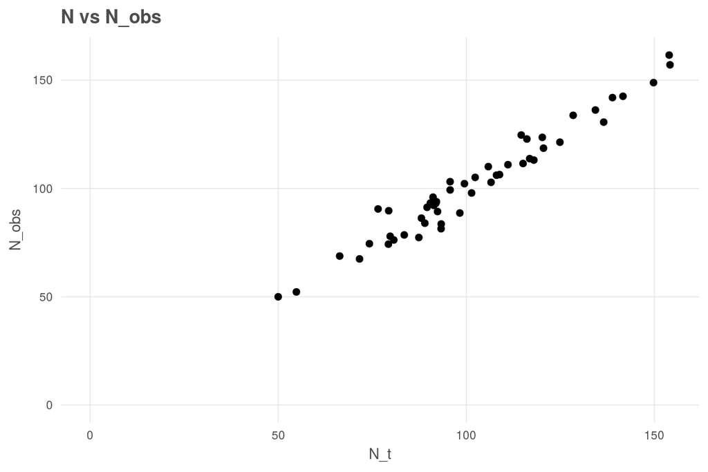

```r
ggplot(pop_1, aes(x = N_t, y = N_obs)) +
  ggtheme_plot() +
  geom_point() +
  xlim(c(0, NA)) + ylim(c(0, NA)) +
  labs(title = 'N vs N_obs')
```

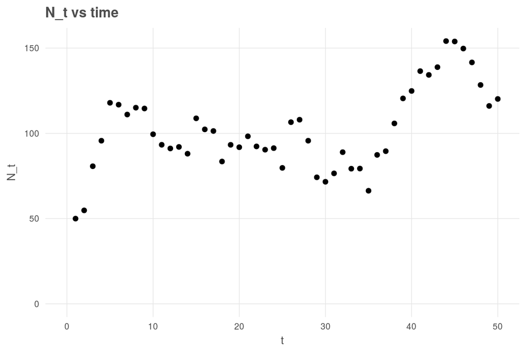

```r
ggplot(pop_1, aes(x = t, y = N_t)) +
  ggtheme_plot() +
  geom_point() +
  xlim(c(0, NA)) + ylim(c(0, NA)) +
  labs(title = 'N_t vs time')
```